# PISA 2012: A RESEARCH ABOUT CHILDREN ABILITY

# PISA is a survey of students' skills and knowledge as they approach the end of compulsory education.

# Number of students in each country

We can see that the top ten countries that have the most students to attend this assessment include Mexico, Italy, Spain, Canada, Brazil, Aussie, UK, UAE, Swiss, and Qatar

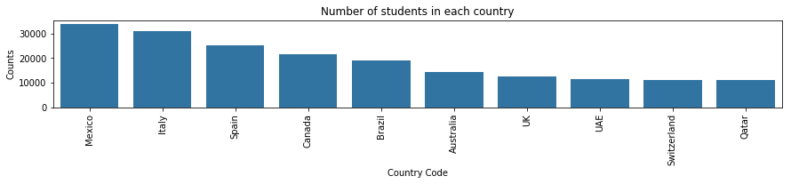

```python
plt.figure(figsize = [14.70, 8.27])

plt.subplot(4, 1, 1)
base_color = sb.color_palette()[0]
sb.countplot(data = df_clean, x = 'Country Code', color = base_color, order=df_clean['Country Code'].value_counts().index[:10])
plt.title('Number of students in each country')
plt.xticks(rotation='vertical');
plt.ylabel('Counts');
```

# Student birth country statistics

There is slightly a difference in this table compared to the one above. Even though the students attending the survey is from those ten countries above, they originally come from countries like China, USA other than UAE, Swiss, Qatar.

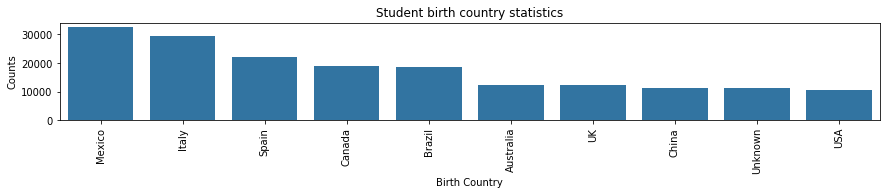

```python
plt.figure(figsize = [14.70, 8.27])

plt.subplot(4, 1, 2)
base_color = sb.color_palette()[0]
sb.countplot(data = df_clean, x = 'Birth Country', color = base_color, order=df_clean['Birth Country'].value_counts().index[:10])
plt.title('Student birth country statistics')
plt.xticks(rotation='vertical');
plt.ylabel('Counts');
```

# The difference in scores between male and female students

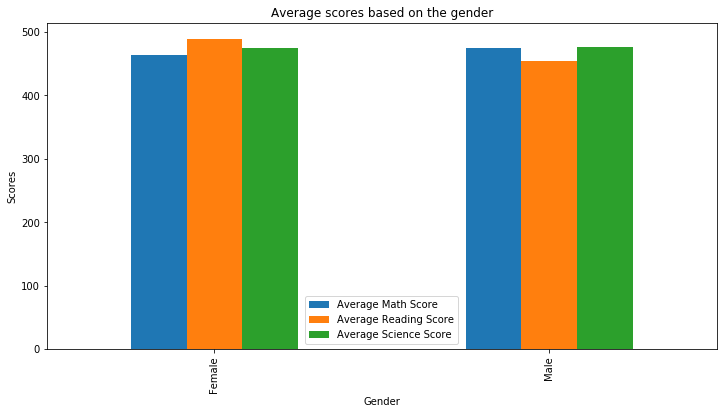

```python
res = df_clean.groupby(['Gender']).mean()[['Average Math Score', 'Average Reading Score', 'Average Science Score']]
ax = res.plot.bar(figsize=(12,6));
plt.ylabel('Scores')
plt.title('Average scores based on the gender');
```

# In general, boys score higher than girls in math whilst girls are prominent in reading. They have similiar score in science.

# Observation of the impact of parents at home accompanying students and their performance

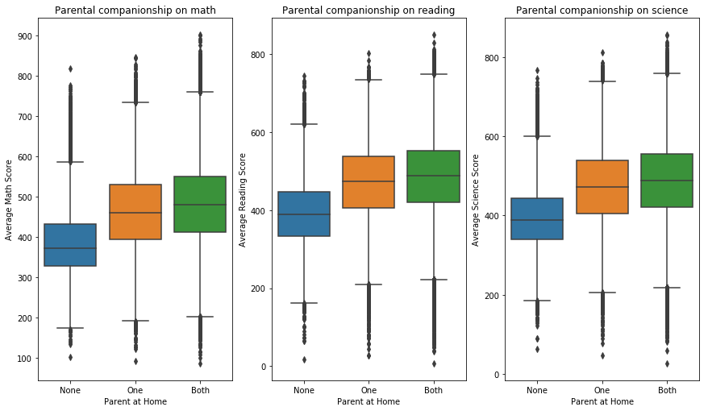

```python
plt.figure(figsize = [14.70, 8.27])
base_color = sb.color_palette()[0]
order = ['None', 'One', 'Both']
plt.subplot(1, 3, 1)
sb.boxplot(x = df_clean['Parent at Home'], y = df_clean['Average Math Score'], order=order);
plt.title('Parental companionship on math');
plt.subplot(1, 3, 2)
sb.boxplot(x = df_clean['Parent at Home'], y = df_clean['Average Reading Score'], order=order);
plt.title('Parental companionship on reading');
plt.subplot(1, 3, 3)
sb.boxplot(x = df_clean['Parent at Home'], y = df_clean['Average Science Score'], order=order);
plt.title('Parental companionship on science');
```